```r
# This file contains the study on impact factor and replicability
```

# Study 2: Journal-Level Citation Metrics and Replicability

To examine whether journal-level citation impact (OpenAlex Mean Citedness, OMC) is associated with replication success, we conducted an exploratory study of secondary data. We modelled replication outcome as a binary variable (0 = failure, 1 = success) and used the log-transformed OMC as the predictor. Analyses were conducted separately for the most recent full FLoRA database and the GutheR subsample. For each dataset we (a) verified the logistic regression linearity-in-log-odds assumption via the Box–Tidwell test, (b) fitted a logistic regression with log-transformed OMC, (c) fitted a Generalized Additive Model (GAM) to capture potential non-linear effects, and (d) tested whether scientific discipline confounds the OMC–replicability relationship using mixed-effects logistic regression with a random intercept for discipline. Because the Box–Tidwell test indicated a remaining violation of the linearity assumption even after log-transformation in the GutheR subsample, we additionally fitted a Restricted Cubic Splines (RCS) logistic regression for that dataset. The analyses were not preregistered.

## Descriptive Overview

The distributions of OMC values were similar across both datasets, with the majority of studies falling in the range 0 < OMC < 8 (see Figure @ref(fig:omc-plot-hist)).

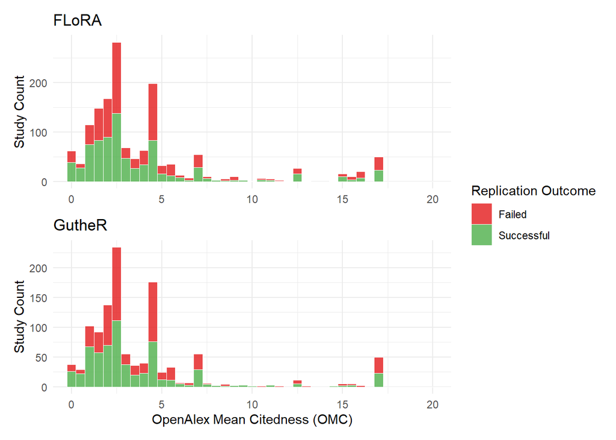

## Results

Across both datasets, higher OMC was negatively associated with replication success: studies published in journals with higher mean citedness were somewhat *less* likely to be successfully replicated.

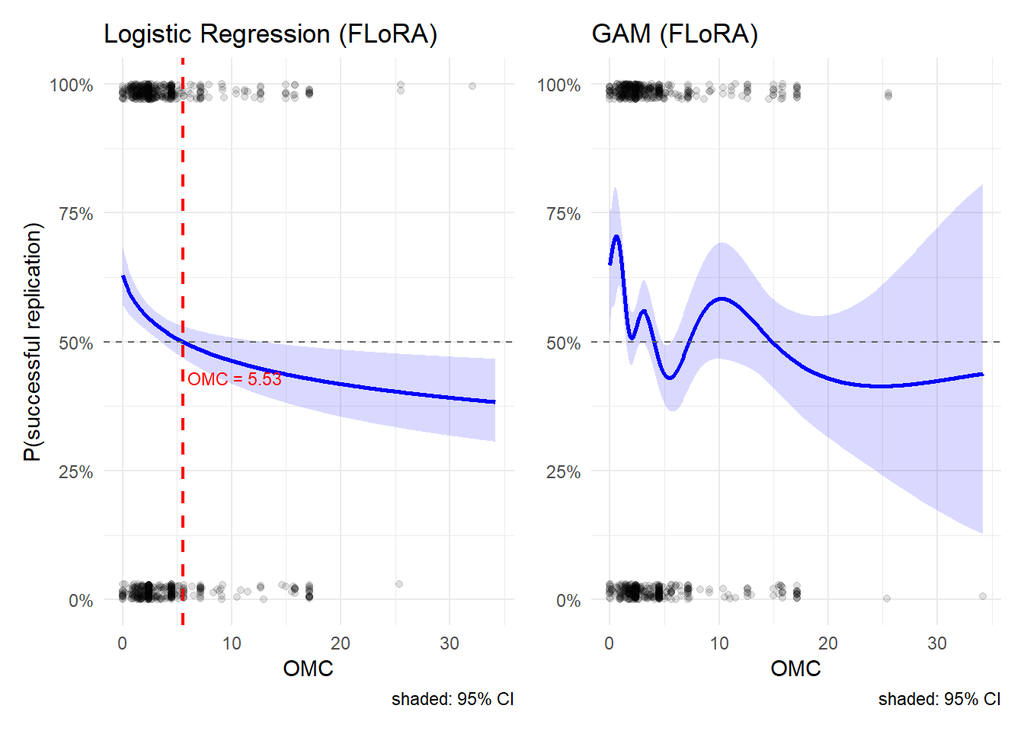

Predicted probability of successful replication as a function of OMC in the FLoRA database. Left: logistic regression with log-transformed OMC. Right: GAM. Shaded bands represent 95% confidence intervals. The dashed red vertical line marks the OMC value at which P(success) = 0.50 (logistic model only).

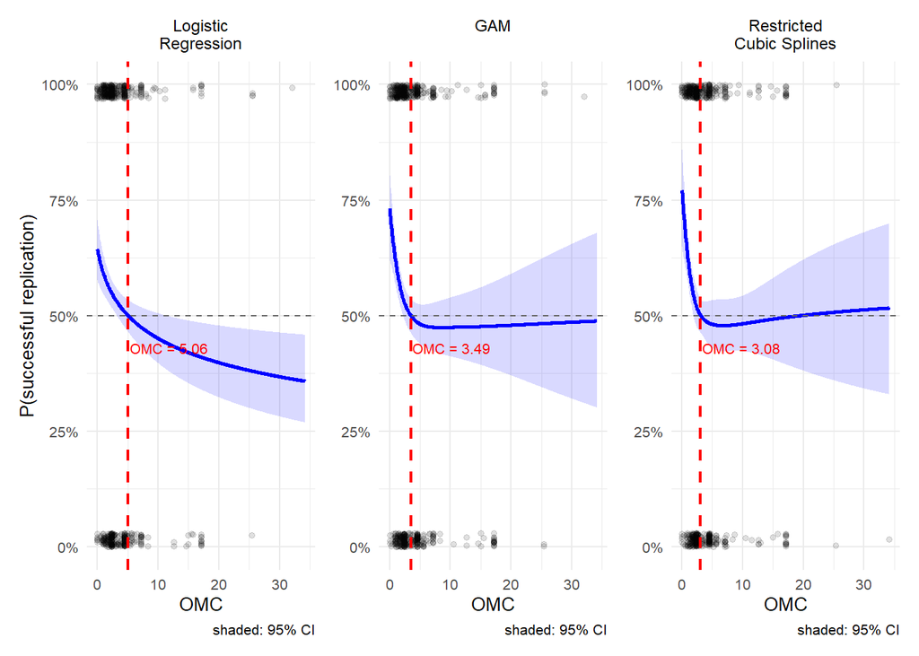

Predicted probability of successful replication as a function of OMC in the GutheR subsample. From left to right: logistic regression, GAM, and Restricted Cubic Splines (RCS). The RCS model was added because the Box–Tidwell test indicated a remaining non-linearity after log-transformation. Shaded bands represent 95% confidence intervals; dashed red vertical lines indicate OMC values at which P(success) = 0.50.

**Role of scientific discipline.** Multilevel logistic regression with a random intercept for scientific discipline revealed that discipline accounts for a small share of variance in replication outcomes in both datasets (ICC<sub>FLoRA</sub> = 0.046, ICC<sub>GutheR</sub> = 0.052), indicating that OMC and discipline are partially confounded. Nevertheless, OMC retained a small but statistically significant independent effect in both datasets after accounting for disciplinary clustering (FLoRA: $\hat\beta$ = -0.34, *p* < .001; GutheR: $\hat\beta$ = -0.4, *p* < .001). The overlap between the two datasets and the distribution of OMC values are shown in Figure @ref(fig:omc-plot-compare). Model diagnostics, including DHARMa residual simulations, overdispersion tests, outlier tests, and perfect-separation checks, indicated no violations of modelling assumptions in either dataset.

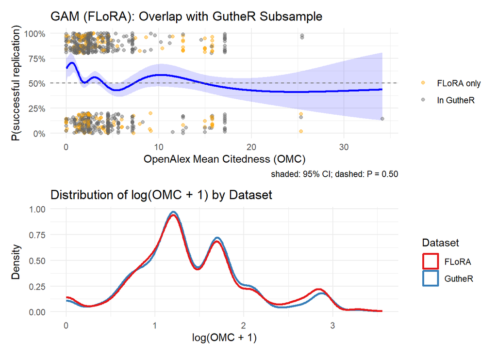

Top: GAM prediction curve for the FLoRA database, with individual studies colour-coded by whether they are also included in the GutheR subsample (grey) or appear only in FLoRA (orange). Bottom: distribution of log-transformed OMC values for both datasets.

## Discussion

Taken together, while the negative effect of OMC on replication success is statistically detectable and robust across model specifications and datasets, its explanatory power is too limited for journal-level citation metrics to serve as a meaningful heuristic for judging the replicability of individual studies.